# Custom KD-tree Based Reverse Geocoder Function in R

Lucien Baumgartner

10/12/2018

## Function

```r
library(geosphere)
library(ggplot2)
library(tidyr)
library(rgdal)
library(geonames)
library(viridis)

rm(list = ls())

# load the new datasets (JSON-streaming)
load('~/Twitter-SY/Twitter-SY/output/00-dataframes.RData')

# source reverse-geocoding fx
source('~/r-helpers/reverse-geocoding/reverse-geocoding-fx.R')

# this is the fuunction
reverse_geocode_city
```

```
## function (data, query, geo.source.coordinates = geonames.coord,
##     geo.source.full = geonames.df, n.nearest.neighbours, n.cores = NULL)
## {
##     if (is.null(n.cores))
##         n.cores <- detectCores() - (round(detectCores()/2, 0))
##     df <- data %>% select(id, geo.coordinates.0, geo.coordinates.1,
##         grep("bounding_box", names(data), value = T)) %>% setNames(.,
##         c("id", "geo.coord.lat", "geo.coord.lng", paste0("bounding_box_",
##             grep("bounding_box", names(data), value = T) %>%
##                 gsub(".*[A-z]{1,}\\.0\\.", "", .) %>% as.numeric %>%
##                 format(as.vector(as.vector(.) + 1), digits = 1) %>%
##                 gsub("0$", "lng", .) %>% gsub("1$", "lat", .)))) %>%
##         mutate(coord.L = ifelse(is.na(geo.coord.lat) | is.na(geo.coord.lng),
##             F, T)) %>% as_tibble
##     if (identical(query, "both")) {
##         l.both <- lapply(c("bounding_box", "geo.coord"), function(query) {
##             if (identical(query, "bounding_box")) {
##                 df.base <- filter(df, coord.L == F)
##                 query.lng <- paste0(query, ".*\\.lng")
##                 query.lat <- paste0(query, ".*\\.lat")
##                 n.points.polygon <- length(grep("bounding_box",
##                   names(data)))
##                 l.query <- tibble(lat = c(t(df.base[grepl(query.lat,
##                   names(df.base))])), lng = c(t(df.base[grepl(query.lng,
##                   names(df.base))])), group = rep(c(1:(length(lng)/4)),
##                   each = 4)) %>% split.data.frame(., .$group) %>%
##                   pbmclapply(., function(x) select(x, -group),
##                     mc.cores = n.cores)
##                 print("[STATUS] bounding boxes: set up")
##                 sp.poly.query <- pbmclapply(l.query, function(x) {
##                   tmp <- Polygon(x)
##                   tmp <- Polygons(list(tmp), 1)
##                   tmp <- SpatialPolygons(list(tmp))
##                   return(tmp)
##                 }, mc.cores = n.cores)
##                 print("[STATUS] polygons: computed")
##                 sp.centroids <- pbmclapply(sp.poly.query, gCentroid,
##                   mc.cores = n.cores)
##                 query <- lapply(sp.centroids, as.data.frame) %>%
##                   do.call(rbind, .)
```

[output cut: 44 more lines]

```
##         }
##     }
##     nns <- nn2(data = select(geo.source.coordinates, -id), query = query)
##     ids <- geo.source.coordinates$id[nns$nn.idx[, 1:n.nearest.neighbours]]
##     city <- tibble(city.id = as.numeric(geo.source.full$id[geo.source.full$id %in%
##         ids]), city = geo.source.full$name[geo.source.full$id %in%
##         ids], city.lat = as.numeric(geo.source.full$lat[geo.source.full$id %in%
##         ids]), city.lng = as.numeric(geo.source.full$lng[geo.source.full$id %in%
##         ids])) %>% left_join(tibble(city.id = ids), ., by = "city.id")
##     df.base <- as_tibble(cbind(df.base, city))
##     df <- left_join(df, df.base, by = names(df.base)[names(df.base) %in%
##         names(df)])
##     print("[STATUS] nearest neighbours: computed")
##     return(df)
## }
```

The function autamtically loads the geonames dataset for cities with population > 10000 as a source for the reverse geocoding. It is possible to use another source.

## Functionality

For all cases, in which only bounding boxes are available but no precise geo coordinates, the function (i) sets up the bounding boxes, (ii) computes the polygons, and subsequently their (iii) centroids. Those are used then used to compute the nearest neighbours. When geo coordinates are available, they extracted and directly used to compute the nearest neighbours. If both options shall be used (like in our case), it will do both. Nearest neighbour results based on geo coordinates will always override bounding box-only results. Ultimately, the function returns the same dataframe that was fed to it, complemented with the new geoinformation. At the moment, the function only supports these new variables:`city.id` (geoNames), `city` (name), `city.lat`, `city.lng`. The coordinates are returned for validation purposes (see below). I’ll add country infomration, asap.

In the following there is a test run with the Syria Twitter Data 2015. It shows that the python library (reverseGeocoder) and my function produce the exact same results in 98.87% of all cases.

In 68.96% of the remaining cases (those that differ), my function maps them more accurately than the python library.

## Test run

```r
# compute nearest city for 2015 data
my.rec <- reverse_geocode_city(data=dfl[[2]],
                               query = 'both',
                               n.nearest.neighbours = 1)
```

```
## [1] "[STATUS] bounding boxes: set up"
## [1] "[STATUS] polygons: computed"
## [1] "[STATUS] centroids: computed"
## [1] "[STATUS] geocoordinates: extracted"
## [1] "[STATUS] nearest neighbours: computed"
```

```r
head(as.data.frame(my.rec))
```

```
##             id geo.coord.lat geo.coord.lng bounding_box_0.lng
## 1 5.504416e+17      33.51670      36.31670            35.7234
## 2 5.504719e+17            NA            NA            35.7234
## 3 5.504419e+17            NA            NA            35.7234
## 4 5.504726e+17            NA            NA            35.7234
## 5 5.504576e+17      33.52207      36.28733            35.7234
## 6 5.504423e+17      35.37503      35.98195            35.7234
##   bounding_box_0.lat bounding_box_1.lng bounding_box_1.lat
## 1           32.31304            35.7234           37.32491
## 2           32.31304            35.7234           37.32491
## 3           32.31304            35.7234           37.32491
## 4           32.31304            35.7234           37.32491
## 5           32.31304            35.7234           37.32491
## 6           32.31304            35.7234           37.32491
##   bounding_box_2.lng bounding_box_2.lat bounding_box_3.lng
## 1           42.37719           37.32491           42.37719
## 2           42.37719           37.32491           42.37719
## 3           42.37719           37.32491           42.37719
## 4           42.37719           37.32491           42.37719
## 5           42.37719           37.32491           42.37719
## 6           42.37719           37.32491           42.37719
##   bounding_box_3.lat coord.L city.id        city city.lat city.lng
## 1           32.31304    TRUE  170654    Damascus 33.51020 36.29128
## 2           32.31304   FALSE  172425  As Sukhnah 34.88533 38.87110
## 3           32.31304   FALSE  172425  As Sukhnah 34.88533 38.87110
## 4           32.31304   FALSE  172425  As Sukhnah 34.88533 38.87110
## 5           32.31304    TRUE  170654    Damascus 33.51020 36.29128
## 6           32.31304    TRUE  172172 ‘Ayn Shiqāq 35.39441 36.03012
```

```r
#load initial datasets
setwd('~/Dropbox/Twitter_Syria/data/input/')

df <- lapply(grep('Location.csv', list.files(), value=T),
             function(x) read.csv(x, stringsAsFactors=FALSE, sep='\t'))
# subset for 2015 data
sc.rec <- df[[1]]

# join both sets together
recs <- left_join(sc.rec %>% mutate(id=as.numeric(id)), my.rec %>% rename(newcity=city), by='id')

# ex:
tail(sort(table(recs$newcity)), 20)
```

```
##
##  As Suwaydā’     Sahnaiya    Kafranbel    Ar Raqqah Ash Shajarah
##          429          463          500          586          743
##      Ḩarastā       Babīlā       Al Bāb       Jablah      Ad Dānā
##          800          969         1018         1150         1349
##     Tartouss      Dārayyā        Ḩamāh     Jaramānā         Homs
##         1690         2308         2425         2991         3190
##     Qadsayyā       Aleppo      Latakia     Damascus   As Sukhnah
##         3807         5449         8138        14311        61639
```

```r
# preprocess the city names
recs <- recs %>%
  filter(!city_use==newcity) %>%
  select(city, city_use, newcity, geo.coordinates, city.lat, city.lng, geo.coord.lat, geo.coord.lng) %>%
  mutate(geo.coordinates=gsub('\\]|\\[|,', '', geo.coordinates)) %>%
  separate(., geo.coordinates, c('lat', 'lng'), sep = '\\s')  %>%
  mutate_at(grep('lat|lng', names(.), value=T), as.numeric) %>%
  mutate_at(grep('city', names(.), value=T), .funs = function(x) iconv(x, from = 'UTF-8', 'ASCII//TRANSLIT') %>%
              gsub("['`^]", '', .) %>%
              gsub('["]', '', .)) %>%
  as_tibble %>%
  na.omit %>%
  mutate(newcity=recode(newcity,
                        Qadsayya='Qadsiya',
                        Kafranbel='Kafr Nubl',
                        Bdama='Badama',
                        Mismiyah='Al Mismiyah',
                        'Ad Duraykish'='Duraykish',
                        Fukuoka='Fukuoka-shi'
  ))

# subset the cases where the city info differs
recs.s <- recs %>%
  filter(!(city==newcity|city==""))

# share of identical results:
1-(nrow(recs.s)/nrow(recs))
```

```
## [1] 0.9887212
```

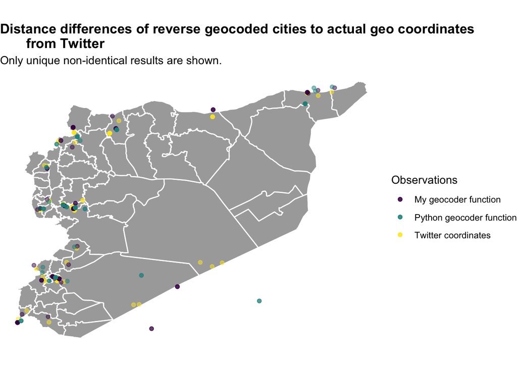

```r
options(geonamesUsername="dtalab")

# get the coordinates for the cities already coded in the data to match it to the coordinates I reverse geocoded
gloc <- pbmclapply(unique(recs.s$city), function(x){
  temp <- tryCatch(GNsearch(name=x) %>% mutate(locs=x) , error=function(err) NA)
  return(temp)}, mc.cores = 2) %>%
  do.call(rbind, .)

geo <- gloc %>%
  filter(!duplicated(locs)) %>%
  select(gn.lat=lat, gn.lng=lng, city=locs)

geo <- left_join(recs.s, geo, by='city') %>%
  mutate_at(grep('lat|lng', names(.), value=T), .funs=as.numeric) %>%
  unique

# plot
setwd('~/Twitter-SY/Twitter-SY/input/syr_admin_shp_utf8_180131/')
admin <- readOGR('.','syr_admin2')
admin <- fortify(admin)

q <- ggplot(geo) +
  geom_polygon(data=admin, aes(long, lat, group=group), fill='darkgrey', color='white') +
  geom_point(aes(geo.coord.lng, geo.coord.lat, color='Twitter coordinates'), alpha=0.5) +
  geom_point(aes(city.lng, city.lat, color='My geocoder function'), alpha=0.5) +
  geom_point(aes(gn.lng, gn.lat, color='Python geocoder function'), alpha=0.5) +
  theme_void() +
  theme(plot.title = element_text(face='bold')) +
  scale_x_continuous(limits = range(admin$long)) +
  scale_y_continuous(limits = range(admin$lat)) +
  coord_equal() +
  scale_color_viridis(discrete = T, name='Observations') +
  labs(title='Distance differences of reverse geocoded cities to actual geo coordinates
       from Twitter',
       subtitle='Only unique non-identical results are shown.')
q
```

```r
# which function produces better results?
geo <- pbmclapply(1:nrow(geo), function(x){
  my <- distHaversine(select(geo, geo.coord.lng, geo.coord.lat)[x,],
                      select(geo, city.lng, city.lat)[x,])
  or <- distHaversine(select(geo, geo.coord.lng, geo.coord.lat)[x,],
                      select(geo, gn.lng, gn.lat)[x,])
  return(list(my, or))
},
mc.cores=4) %>%
  tibble(my=sapply(., '[[', 1),
         or=sapply(., '[[', 2)) %>%
  mutate(better=my<or)

# share of cases with non-identical results where the resulting city data from my function is nearer to the actaul geo coordinates than the python library
table(geo$better)/nrow(geo)
```

```
##
##     FALSE      TRUE
## 0.3103448 0.6896552
```